# Blockchain

Introductie in Blockchain, cryptocurrencies en Smart Contracts.

Bèr `berkes` Kessels

## Over Bèr Kessels

- Bèr Kessels
- https://{twitter.com,reddit.com/u,linkedin.com/in}/berkes
- Oprichter PlaceBazaar

## Over mij en Blockchain (Full Disclosure)

- April 2011 begonnen met Bitcoin
- Heeft portfolio met technisch interessante Crypto-assets
  - Bitcoin, Ethereum, Stellar, en diverse ICO tokens
- Oprichter van een crypto startup PlaceBazaar

## Advies en development van blockchain platforms

- Toespitsen op **jouw** idee
- Uitzoeken waar voor **jouw** niche de kansen liggen
- Schrijven van Whitepaper
- Ontwikkeling van smart contracts, blockchain-platforms en distributed apps (dApps)

## Waar kan ik deze workshop nog meer geven?

- Scholen?
- Bedrijven?
- Netwerkbijeenkomsten?
- Contacten?

Geef het door!

## Over de presentatie

- Staat op berk.es/blockchainpres
- Bron: git.webschuur.com/berkes/blockchainpres
- URL komt aan het eind voorbij

## Inhoud

- Bitcoin en Blockchain
- Smart Contracts
- Toepassingen
- De Hype

## Wat is Blockchain?

Een onveranderlijk, gedistribueerd grootboek

*An Immutable, Distributed Ledger*

## Wat bedoelen we met een grootboek?

Een database met daarin opeenvolgende transacties:

Beginstand: Anne: 6, Bob 0, Carol 1

1. **Anne** geeft 5 aan **Bob**
2. **Bob** geeft 2 aan **Carol**
3. **Carol** geeft 1 aan **Anne**

## Gedistribueerd:

### Doen!

## Centraal, Decentraal, Gedistribueerd

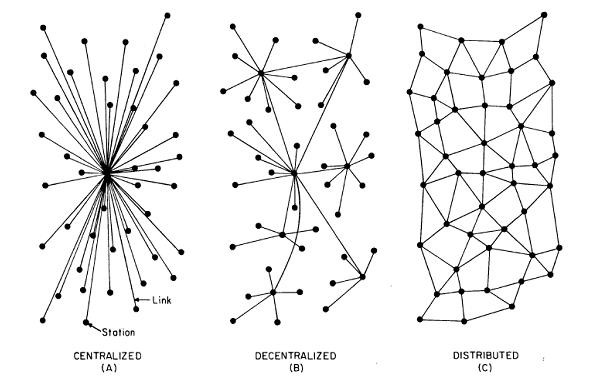

Centraal vs Decentraal vs Gedistribueerd

## Wat zagen we?

Gedistribueerd (cash) is:

- Trustless (vertrouwenloos).
- Permissionless (vergunningsvrij)
- Uncensorable (oncensureerbaar)
- Verifiable (controleerbaar)

## Dat komt voort uit "Distributed"

- Geen centraal "point of failure"
- Kan wereldwijd opschalen
- Heet ook wel "Peer to Peer, P2P"

## Waarom werkt muntgeld?

Ideeën?

## En hoe moet dat digitaal?

- Tot 2008 werd dit onmogelijk geacht
- Altijd via centrale autoriteiten

## Centraal:

### DOEN

## Een blockchain!

Een onveranderlijk, gedistribueerd grootboek!

## Digitaal Gedistribueerd:

### DOEN

- 5 Personen naar voren.
- Krijgen een "digitale kasboek"
- Anne betaalt 2 BTC aan Bob
- Bob probeert aan Carol 3 BTC te betalen
- Carol betaalt 0.5 BTC aan Bob

## DOEN 2

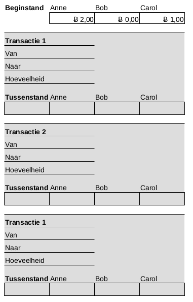

Virtueel kasboek

## Hoe kan dit werken?

Ideeën?

## Onveranderlijk? (Immutable)

- Data kan niet aangepast worden nadat het in het grootboek is weggeschreven
- Data is controleerbaar
- Er is consensus nodig om het grootboek bij te werken

## Wat is consensus?

- "Iedereen" komt overeen wat de huidige status is
  - Bijvoorbeeld: wat zijn de saldi van iedereens rekeningen

## Distributed

- Complex
- Maar zonder centrale partijen!

# Smart Contracts

## Dat kan slimmer!

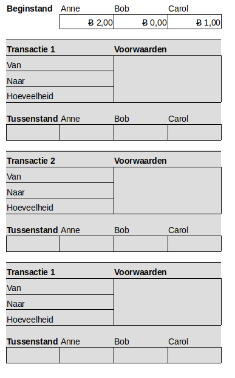

Voorwaarden

## Bijvoorbeeld:

Transactie voor "mijn gehele vermogen" naar "Neef Bob" als Notaris Drs. Ibbelsteijn de transactie ondertekent.

## Slimme transacties

- Na T tijd
- Ondertekend door N van M personen
- Tot bedrag van X.

## Dat kan slimmer!

- Trustless (vertrouwenloos).
- Permissionless (vergunningsvrij)
- Uncensorable (oncensureerbaar)
- Verifiable (controleerbaar)

## Dat kan slimmer!

Transactie voor "mijn gehele vermogen" naar "Neef Bob" als ik een maand lang de transactie *niet* onderteken!

**trustless**

## Meer dan geld

Data, unieke tokens, coupons, eigendomsbewijzen, toegangssleutel, contracten.

## Code is law

Transactie voor "mijn gehele vermogen" naar "Neef Bob" als ik een maand lang de transactie *niet* onderteken!

- Wat als ik een keer vergeet?
- Wat als Neef Bob overleidt?
- Wat als ...

## Heb je een Blockchain nodig?

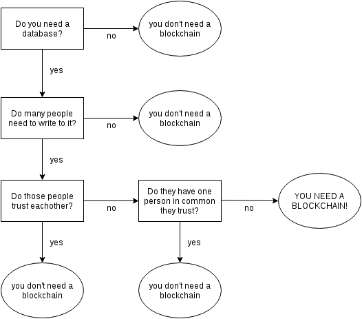

## Jullie usecases?

## Presentatie

- berk.es/blockchainpres
- ber@berk.es